# INN Hotels Project

## Context

A significant number of hotel bookings are called-off due to cancellations or no-shows. The typical reasons for cancellations include change of plans, scheduling conflicts, etc. This is often made easier by the option to do so free of charge or preferably at a low cost which is beneficial to hotel guests but it is a less desirable and possibly revenue-diminishing factor for hotels to deal with. Such losses are particularly high on last-minute cancellations.

The new technologies involving online booking channels have dramatically changed customers’ booking possibilities and behavior. This adds a further dimension to the challenge of how hotels handle cancellations, which are no longer limited to traditional booking and guest characteristics.

The cancellation of bookings impact a hotel on various fronts:

- Loss of resources (revenue) when the hotel cannot resell the room.
- Additional costs of distribution channels by increasing commissions or paying for publicity to help sell these rooms.
- Lowering prices last minute, so the hotel can resell a room, resulting in reducing the profit margin.
- Human resources to make arrangements for the guests.

## Objective

The increasing number of cancellations calls for a Machine Learning based solution that can help in predicting which booking is likely to be canceled. INN Hotels Group has a chain of hotels in Portugal, they are facing problems with the high number of booking cancellations and have reached out to your firm for data-driven solutions. You as a data scientist have to analyze the data provided to find which factors have a high influence on booking cancellations, build a predictive model that can predict which booking is going to be canceled in advance, and help in formulating profitable policies for cancellations and refunds.

## Data Description

The data contains the different attributes of customers' booking details. The detailed data dictionary is given below.

**Data Dictionary**

- Booking_ID: unique identifier of each booking
- no_of_adults: Number of adults
- no_of_children: Number of Children
- no_of_weekend_nights: Number of weekend nights (Saturday or Sunday) the guest stayed or booked to stay at the hotel
- no_of_week_nights: Number of week nights (Monday to Friday) the guest stayed or booked to stay at the hotel
- type_of_meal_plan: Type of meal plan booked by the customer:
  - Not Selected – No meal plan selected
  - Meal Plan 1 – Breakfast
  - Meal Plan 2 – Half board (breakfast and one other meal)
  - Meal Plan 3 – Full board (breakfast, lunch, and dinner)
- required_car_parking_space: Does the customer require a car parking space? (0 - No, 1- Yes)
- room_type_reserved: Type of room reserved by the customer. The values are ciphered (encoded) by INN Hotels.
- lead_time: Number of days between the date of booking and the arrival date
- arrival_year: Year of arrival date
- arrival_month: Month of arrival date
- arrival_date: Date of the month
- market_segment_type: Market segment designation.
- repeated_guest: Is the customer a repeated guest? (0 - No, 1- Yes)
- no_of_previous_cancellations: Number of previous bookings that were canceled by the customer prior to the current booking
- no_of_previous_bookings_not_canceled: Number of previous bookings not canceled by the customer prior to the current booking
- avg_price_per_room: Average price per day of the reservation; prices of the rooms are dynamic. (in euros)
- no_of_special_requests: Total number of special requests made by the customer (e.g. high floor, view from the room, etc)
- booking_status: Flag indicating if the booking was canceled or not.

## Importing necessary libraries and data

```python
import warnings
warnings.filterwarnings("ignore")
#libraries to help with reading and manipulating data
import pandas as pd
import numpy as np
#library to split data
from sklearn.model_selection import train_test_split
#libaries to help with data visualization
import matplotlib.pyplot as plt
import seaborn as sns
#------LOGISTIC REGRESSION------
#libraries to build model for prediction
import statsmodels.stats.api as sms
from statsmodels.stats.outliers_influence import variance_inflation_factor
import statsmodels.api as sm
from statsmodels.tools.tools import add_constant
from sklearn.linear_model import LogisticRegression
#------DECISION TREE------
#libraries to build model for prediction
from sklearn.tree import DecisionTreeClassifier
from sklearn import tree
#libraries to tune different models
from sklearn.model_selection import GridSearchCV

#libraries to get diferent metric scores
from sklearn import metrics
from sklearn.metrics import (
    f1_score,
    accuracy_score,
    recall_score,
    precision_score,
    confusion_matrix,
    roc_auc_score,
    plot_confusion_matrix,
    precision_recall_curve,
    roc_curve,
    make_scorer,
)

pd.set_option('display.float_format', lambda x: '%.5f' % x)
```

```python
from google.colab import drive
drive.mount('/content/drive')
```

```python
data = pd.read_csv("/content/drive/My Drive/PGDSBA/INNHotelsGroup.csv")
```

Creating a working copy of the data

```python
df = data.copy()
```

## Data Overview

- Observations
- Sanity checks

```python
df.head() #displays the first 5 rows of dataframe
```

|  | Booking_ID | no_of_adults | no_of_children | no_of_weekend_nights | no_of_week_nights | type_of_meal_plan | required_car_parking_space | room_type_reserved | lead_time | arrival_year | arrival_month | arrival_date | market_segment_type | repeated_guest | no_of_previous_cancellations | no_of_previous_bookings_not_canceled | avg_price_per_room | no_of_special_requests | booking_status |
| --- | --- | --- | --- | --- | --- | --- | --- | --- | --- | --- | --- | --- | --- | --- | --- | --- | --- | --- | --- |
| 0 | INN00001 | 2 | 0 | 1 | 2 | Meal Plan 1 | 0 | Room_Type 1 | 224 | 2017 | 10 | 2 | Offline | 0 | 0 | 0 | 65.00 | 0 | Not_Canceled |
| 1 | INN00002 | 2 | 0 | 2 | 3 | Not Selected | 0 | Room_Type 1 | 5 | 2018 | 11 | 6 | Online | 0 | 0 | 0 | 106.68 | 1 | Not_Canceled |
| 2 | INN00003 | 1 | 0 | 2 | 1 | Meal Plan 1 | 0 | Room_Type 1 | 1 | 2018 | 2 | 28 | Online | 0 | 0 | 0 | 60.00 | 0 | Canceled |
| 3 | INN00004 | 2 | 0 | 0 | 2 | Meal Plan 1 | 0 | Room_Type 1 | 211 | 2018 | 5 | 20 | Online | 0 | 0 | 0 | 100.00 | 0 | Canceled |
| 4 | INN00005 | 2 | 0 | 1 | 1 | Not Selected | 0 | Room_Type 1 | 48 | 2018 | 4 | 11 | Online | 0 | 0 | 0 | 94.50 | 0 | Canceled |

```python
df.tail() #displays the last 5 rows of dataframe
```

|  | Booking_ID | no_of_adults | no_of_children | no_of_weekend_nights | no_of_week_nights | type_of_meal_plan | required_car_parking_space | room_type_reserved | lead_time | arrival_year | arrival_month | arrival_date | market_segment_type | repeated_guest | no_of_previous_cancellations | no_of_previous_bookings_not_canceled | avg_price_per_room | no_of_special_requests | booking_status |
| --- | --- | --- | --- | --- | --- | --- | --- | --- | --- | --- | --- | --- | --- | --- | --- | --- | --- | --- | --- |
| 36270 | INN36271 | 3 | 0 | 2 | 6 | Meal Plan 1 | 0 | Room_Type 4 | 85 | 2018 | 8 | 3 | Online | 0 | 0 | 0 | 167.80 | 1 | Not_Canceled |
| 36271 | INN36272 | 2 | 0 | 1 | 3 | Meal Plan 1 | 0 | Room_Type 1 | 228 | 2018 | 10 | 17 | Online | 0 | 0 | 0 | 90.95 | 2 | Canceled |
| 36272 | INN36273 | 2 | 0 | 2 | 6 | Meal Plan 1 | 0 | Room_Type 1 | 148 | 2018 | 7 | 1 | Online | 0 | 0 | 0 | 98.39 | 2 | Not_Canceled |
| 36273 | INN36274 | 2 | 0 | 0 | 3 | Not Selected | 0 | Room_Type 1 | 63 | 2018 | 4 | 21 | Online | 0 | 0 | 0 | 94.50 | 0 | Canceled |
| 36274 | INN36275 | 2 | 0 | 1 | 2 | Meal Plan 1 | 0 | Room_Type 1 | 207 | 2018 | 12 | 30 | Offline | 0 | 0 | 0 | 161.67 | 0 | Not_Canceled |

From head() and tail(), we see that the data is loaded properly.

```python
df.shape #displays (no. of rows, no.of columns) in data
```

```
(36275, 19)
```

The given data has 36275 rows and 19 columns.

```python
df.info() #displays the datatype of each column in dataframe
```

```
<class 'pandas.core.frame.DataFrame'>
RangeIndex: 36275 entries, 0 to 36274
Data columns (total 19 columns):
 #   Column                                Non-Null Count  Dtype
---  ------                                --------------  -----
 0   Booking_ID                            36275 non-null  object
 1   no_of_adults                          36275 non-null  int64
 2   no_of_children                        36275 non-null  int64
 3   no_of_weekend_nights                  36275 non-null  int64
 4   no_of_week_nights                     36275 non-null  int64
 5   type_of_meal_plan                     36275 non-null  object
 6   required_car_parking_space            36275 non-null  int64
 7   room_type_reserved                    36275 non-null  object
 8   lead_time                             36275 non-null  int64
 9   arrival_year                          36275 non-null  int64
 10  arrival_month                         36275 non-null  int64
 11  arrival_date                          36275 non-null  int64
 12  market_segment_type                   36275 non-null  object
 13  repeated_guest                        36275 non-null  int64
 14  no_of_previous_cancellations          36275 non-null  int64
 15  no_of_previous_bookings_not_canceled  36275 non-null  int64
 16  avg_price_per_room                    36275 non-null  float64
 17  no_of_special_requests                36275 non-null  int64
 18  booking_status                        36275 non-null  object
dtypes: float64(1), int64(13), object(5)
memory usage: 5.3+ MB
```

- `no_of_adults`, `no_of_children`, `no_of_weekend_nights`, `no_of_week_nights`, `lead_time`, `arrival_year`, `arrival_month`, `arrival_date`, `no_of_previous_cancellations`, `no_of_previous_bookings_not_canceled`, `avg_price_per_room`, `no_of_special_requests` columns are numerical data.
- `type_of_meal_plan`, `required_car_parking_space`, `room_type_reserved`, `market_segment_type`, `repeated_guest`, `booking_status` columns are categorical data.
- `Booking_ID` is a unique id for each booking.

```python
df.duplicated().any() #returns True if any duplicated data found
```

```
False
```

```python
df['Booking_ID'].nunique()
```

```
36275
```

Booking IDs are unique, and we see there are 36275 unique values. There are no duplicates in the given data.

```python
df.isnull().sum() #checks for missing values in each column of the data
```

```
Booking_ID                              0
no_of_adults                            0
no_of_children                          0
no_of_weekend_nights                    0
no_of_week_nights                       0
type_of_meal_plan                       0
required_car_parking_space              0
room_type_reserved                      0
lead_time                               0
arrival_year                            0
arrival_month                           0
arrival_date                            0
market_segment_type                     0
repeated_guest                          0
no_of_previous_cancellations            0
no_of_previous_bookings_not_canceled    0
avg_price_per_room                      0
no_of_special_requests                  0
booking_status                          0
dtype: int64
```

There are no missing values in the data.

```python
df.describe().T #gives statistical summary of the dataframe
```

|  | count | mean | std | min | 25% | 50% | 75% | max |
| --- | --- | --- | --- | --- | --- | --- | --- | --- |
| no_of_adults | 36275.0 | 1.844962 | 0.518715 | 0.0 | 2.0 | 2.00 | 2.0 | 4.0 |
| no_of_children | 36275.0 | 0.105279 | 0.402648 | 0.0 | 0.0 | 0.00 | 0.0 | 10.0 |
| no_of_weekend_nights | 36275.0 | 0.810724 | 0.870644 | 0.0 | 0.0 | 1.00 | 2.0 | 7.0 |
| no_of_week_nights | 36275.0 | 2.204300 | 1.410905 | 0.0 | 1.0 | 2.00 | 3.0 | 17.0 |
| required_car_parking_space | 36275.0 | 0.030986 | 0.173281 | 0.0 | 0.0 | 0.00 | 0.0 | 1.0 |
| lead_time | 36275.0 | 85.232557 | 85.930817 | 0.0 | 17.0 | 57.00 | 126.0 | 443.0 |
| arrival_year | 36275.0 | 2017.820427 | 0.383836 | 2017.0 | 2018.0 | 2018.00 | 2018.0 | 2018.0 |
| arrival_month | 36275.0 | 7.423653 | 3.069894 | 1.0 | 5.0 | 8.00 | 10.0 | 12.0 |
| arrival_date | 36275.0 | 15.596995 | 8.740447 | 1.0 | 8.0 | 16.00 | 23.0 | 31.0 |
| repeated_guest | 36275.0 | 0.025637 | 0.158053 | 0.0 | 0.0 | 0.00 | 0.0 | 1.0 |
| no_of_previous_cancellations | 36275.0 | 0.023349 | 0.368331 | 0.0 | 0.0 | 0.00 | 0.0 | 13.0 |
| no_of_previous_bookings_not_canceled | 36275.0 | 0.153411 | 1.754171 | 0.0 | 0.0 | 0.00 | 0.0 | 58.0 |
| avg_price_per_room | 36275.0 | 103.423539 | 35.089424 | 0.0 | 80.3 | 99.45 | 120.0 | 540.0 |
| no_of_special_requests | 36275.0 | 0.619655 | 0.786236 | 0.0 | 0.0 | 0.00 | 1.0 | 5.0 |

- Median count of number of adults in a booking is 2, and the maximum count is 4.
- Median count of number of children in a booking is 0, and the maximum count is 10.
- Given that the prices of the rooms are dynamic, the mean value of `avg_price_per_room` is 103.42 euros. The minimum average price per room is 0.0, and the maximum is 540 euros.
- Majority of the bookings have not requested for car parking space.
- There are very less number of repeated guests.
- The average number of days between the date of booking and the arrival date is 85.23, the minimum is 0 and the maximum is 443.

```python
#exploring the counts for options in different categorical columns
categorical_cols = ['type_of_meal_plan', 'required_car_parking_space',
                    'room_type_reserved', 'market_segment_type',
                    'repeated_guest', 'booking_status']

for col in categorical_cols:
  print(df[col].value_counts(normalize=True).sort_values(ascending = False))
  print("_" * 75)
```

```
Meal Plan 1     0.767333
Not Selected    0.141420
Meal Plan 2     0.091110
Meal Plan 3     0.000138
Name: type_of_meal_plan, dtype: float64
___________________________________________________________________________
0    0.969014
1    0.030986
Name: required_car_parking_space, dtype: float64
___________________________________________________________________________
Room_Type 1    0.775465
Room_Type 4    0.166975
Room_Type 6    0.026630
Room_Type 2    0.019076
Room_Type 5    0.007305
Room_Type 7    0.004356
Room_Type 3    0.000193
Name: room_type_reserved, dtype: float64
___________________________________________________________________________
Online           0.639945
Offline          0.290227
Corporate        0.055603
Complementary    0.010779
Aviation         0.003446
Name: market_segment_type, dtype: float64
___________________________________________________________________________
0    0.974363
1    0.025637
Name: repeated_guest, dtype: float64
___________________________________________________________________________
Not_Canceled    0.672364
Canceled        0.327636
Name: booking_status, dtype: float64
___________________________________________________________________________
```

- About 77% of bookings have opted for Meal Plan 1 as `type_of_meal_plan` and Meal Plan 3 is the least preferred.
- 97% of the bookings have not requested for car parking.
- 77.5% of the bookings have reserved Room_Type 1, Room_type 3 is the least preferred.
- About 64% of `market_segment_type` is Online, followed by Offline - 29%.
- Only 2.56% of the bookings are done by repeated customers.
- 67.2% of the bookings were not cancelled.

## Exploratory Data Analysis (EDA)

- EDA is an important part of any project involving data.
- It is important to investigate and understand the data better before building a model with it.
- A few questions have been mentioned below which will help you approach the analysis in the right manner and generate insights from the data.
- A thorough analysis of the data, in addition to the questions mentioned below, should be done.

**Leading Questions**:

1. What are the busiest months in the hotel?
2. Which market segment do most of the guests come from?
3. Hotel rates are dynamic and change according to demand and customer demographics. What are the differences in room prices in different market segments?
4. What percentage of bookings are canceled?
5. Repeating guests are the guests who stay in the hotel often and are important to brand equity. What percentage of repeating guests cancel?
6. Many guests have special requirements when booking a hotel room. Do these requirements affect booking cancellation?

### Univariate Analysis

```python
# function to create plots for attributes
# histogram plot with kde
def histplot_with_kde(data, attribute, kde=True):
  plt.figure(figsize=[15,7])
  sns.histplot(data=data, x=attribute);
  plt.show()
# boxplot
def boxplot(data, attribute):
  sns.boxplot(data=data, x=attribute);
  plt.show()
```

1. Analysing `no_of_adults`

```python
df['no_of_adults'].unique()
```

```
array([2, 1, 3, 0, 4])
```

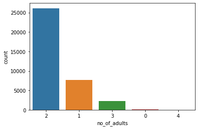

```python
sns.countplot(data=df, x='no_of_adults', order = df['no_of_adults'].value_counts(ascending=False).index);
plt.show()
```

- Maximum number of bookings have 2 adults.
- We see bookings having 4 adults.
- There are bookings with no adults, we need to further investigate on this.
1. Analysing `no_of_children`

```python
df['no_of_children'].unique()
```

```
array([ 0,  2,  1,  3, 10,  9])
```

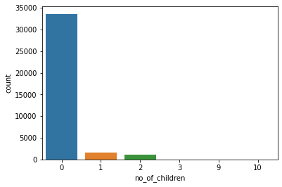

```python
sns.countplot(data=df, x='no_of_children', order = df['no_of_children'].value_counts(ascending=False).index);
plt.show()
```

- Maximum bookings have no children included.
- There are bookings having 1 or 2 children.
- We see bookings for 9 and 10 children, we need to further investigate on this.

```python
df[df['no_of_children'] == 9].shape[0]
```

```
2
```

```python
df[df['no_of_children'] == 10].shape[0]
```

```
1
```

- The entries with 9 and 10 children are outliers.
1. Analysing `no_of_weekend_nights`

```python
df['no_of_weekend_nights'].unique()
```

```
array([1, 2, 0, 4, 3, 6, 5, 7])
```

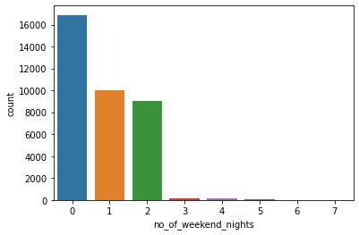

```python
sns.countplot(data=df, x='no_of_weekend_nights', order = df['no_of_weekend_nights'].value_counts(ascending=False).index);
plt.show()
```

- Mostly weekend night (Saturday or Sunday) bookings are less.
- There are good number of bookings for 1 and 2 weekend nights.
- We see some entries for 5+ weekend nights, we shall investigate further.

```python
df[df['no_of_weekend_nights']>5].shape[0]
```

```
21
```

- 21 bookings have 5+ weekend nights.
1. Analysing `no_of_week_nights`

```python
df['no_of_week_nights'].unique()
```

```
array([ 2,  3,  1,  4,  5,  0, 10,  6, 11,  7, 15,  9, 13,  8, 14, 12, 17,
       16])
```

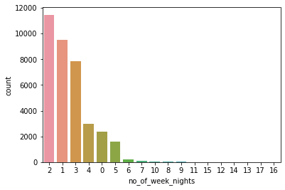

```python
sns.countplot(data=df, x='no_of_week_nights', order = df['no_of_week_nights'].value_counts(ascending=False).index);
plt.show()
```

- Maximum number of weeknights (Monday to Friday) in bookings is 2, followed by 1 and 3.
- We see bookings for 10+ week nights, and we shall investigate further.

```python
df[df['no_of_week_nights']>10].shape[0]
```

```
53
```

- 53 bookings have 10+ week nights.
1. Analysing `type_of_meal_plan`

```python
df['type_of_meal_plan'].unique()
```

```
array(['Meal Plan 1', 'Not Selected', 'Meal Plan 2', 'Meal Plan 3'],
      dtype=object)
```

- There are 3 different meal plans available.

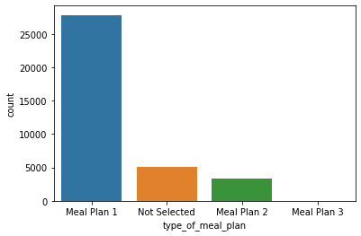

```python
sns.countplot(data=df, x='type_of_meal_plan', order = df['type_of_meal_plan'].value_counts(ascending=False).index);
plt.show()
```

- Most of the bookings opt for Meal Plan 1.
- There are bookings where meal plan was not selected, followed by Meal Plan 2.
- Meal Plan 3 is the least preferred.
1. Analysing `required_car_parking_space`

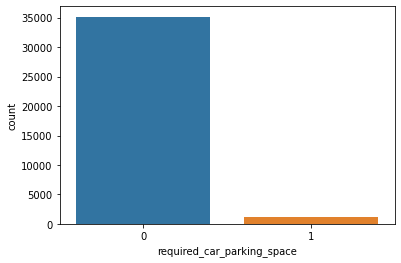

```python
sns.countplot(data=df, x='required_car_parking_space', order = df['required_car_parking_space'].value_counts(ascending=False).index);
plt.show()
```

- Most of the bookings do not require a car parking space.
1. Analysing `room_type_reserved`

```python
df['room_type_reserved'].unique()
```

```
array(['Room_Type 1', 'Room_Type 4', 'Room_Type 2', 'Room_Type 6',
       'Room_Type 5', 'Room_Type 7', 'Room_Type 3'], dtype=object)
```

- There are 7 different room types available for reservation.

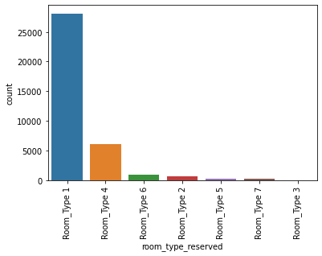

```python
sns.countplot(data=df, x='room_type_reserved', order = df['room_type_reserved'].value_counts(ascending=False).index);
plt.xticks(rotation=90)
plt.show()
```

- Room type 1 is the most reserved, followed by type 4 and type 6.
- Reservations for room type 3 is the least.
1. Analysing `lead_time`

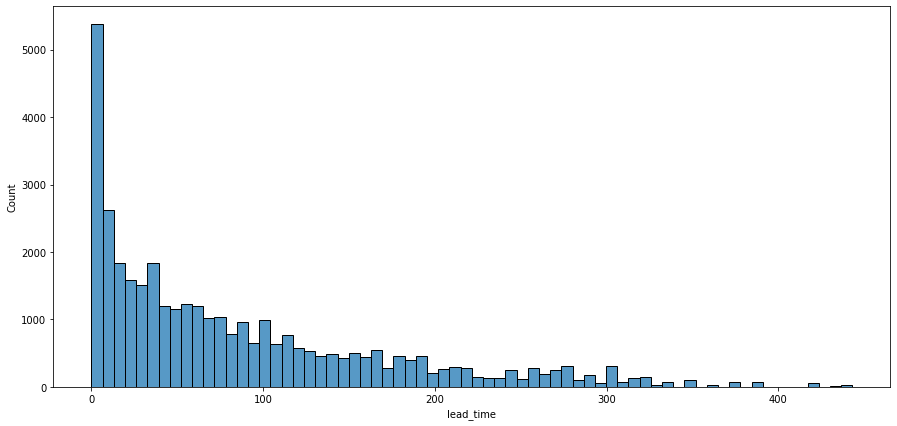

```python
histplot_with_kde(df, 'lead_time')
```

- The plot is highly right skewed.
- Maximum number of bookings have no lead time at all.

```python
df[df['lead_time']== 0]['market_segment_type'].value_counts(normalize=True)
```

```
Online           0.607556
Corporate        0.172706
Offline          0.112567
Complementary    0.098689
Aviation         0.008481
Name: market_segment_type, dtype: float64
```

```python
df[df['lead_time']== 0]['booking_status'].value_counts(normalize=True)
```

```
Not_Canceled    0.947571
Canceled        0.052429
Name: booking_status, dtype: float64
```

- 94.76% of bookings with 0 lead time were not canceled.
1. Analysing `arrival_year`

```python
df['arrival_year'].unique()
```

```
array([2017, 2018])
```

We have the booking data of 2 years, 2017 and 2018.

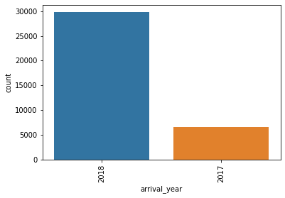

```python
sns.countplot(data=df, x='arrival_year', order = df['arrival_year'].value_counts(ascending=False).index);
plt.xticks(rotation=90)
plt.show()
```

- Number of bookings have increased steeply in 2018, compared to 2017.
1. Analysing `arrival_month`

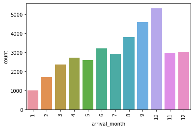

```python
sns.countplot(data=df, x='arrival_month');
plt.xticks(rotation=90)
plt.show()
```

*Qn. 1. What are the busiest months in the hotel?*

```python
df['arrival_month'].value_counts().sort_values(ascending = False)
```

```
10    5317
9     4611
8     3813
6     3203
12    3021
11    2980
7     2920
4     2736
5     2598
3     2358
2     1704
1     1014
Name: arrival_month, dtype: int64
```

*October is the most busiest month, with 5317 bookings. This is followed by September, August, June and December (all 3000+ bookings).*

*January and February are the least busy months.*

1. Analysing `arrival_date`

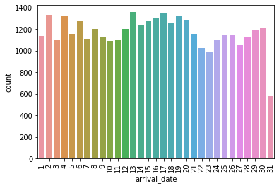

```python
sns.countplot(data=df, x='arrival_date');
plt.xticks(rotation=90)
plt.show()
```

- There is a sharp reduction in the number of bookings in the last day of the month. This could be due to the fact that certain months do not have 31 days.
- Bookings are consistently high for mid-month, 11th to 20th.
1. Analysing `market_segment_type`

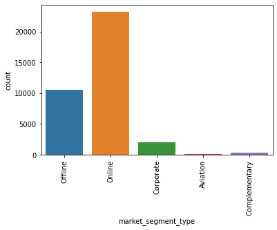

```python
sns.countplot(data=df, x='market_segment_type');
plt.xticks(rotation=90)
plt.show()
```

*Qn. 2. Which market segment do most of the guests come from?*

```python
df['market_segment_type'].value_counts(normalize = True).sort_values(ascending = False)
```

```
Online           0.639945
Offline          0.290227
Corporate        0.055603
Complementary    0.010779
Aviation         0.003446
Name: market_segment_type, dtype: float64
```

1. Analysing `repeated_guest`

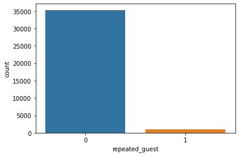

```python
sns.countplot(data=df, x='repeated_guest');
plt.show()
```

- Number of repeating guests are very low.
1. Analysing `no_of_previous_cancellations`

```python
df['no_of_previous_cancellations'].unique()
```

```
array([ 0,  3,  1,  2, 11,  4,  5, 13,  6])
```

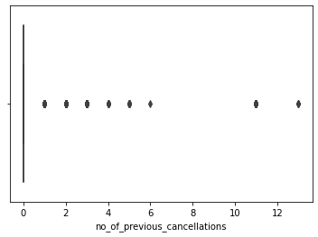

```python
boxplot(df, 'no_of_previous_cancellations')
```

- Most of the times, there were no previous bookings that were canceled by the customer prior to the current booking.
- We see some entries with values greater than 10, we shall investigate further.

```python
df[df['repeated_guest'] == 0]['no_of_previous_cancellations'].value_counts()
```

```
0    35345
Name: no_of_previous_cancellations, dtype: int64
```

- There were no previous bookings that were canceled by the customer prior to the current booking. This goes well with the previous observation, i.e number of repeating guests is very low.

```python
df[df['no_of_previous_cancellations']>10].shape[0]
```

```
29
```

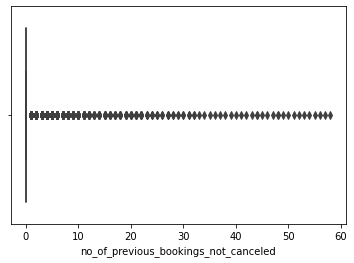

```python
boxplot(df, 'no_of_previous_bookings_not_canceled')
```

- Most of the times, there were no previous bookings that were not canceled by the customer prior to the current booking.

```python
df[df['repeated_guest'] == 0]['no_of_previous_bookings_not_canceled'].value_counts()
```

```
0    35345
Name: no_of_previous_bookings_not_canceled, dtype: int64
```

- There were no previous bookings that were not canceled by the customer prior to the current booking. This goes well with the previous observation, i.e number of repeating guests is very low.
1. Analysing `avg_price_per_room`

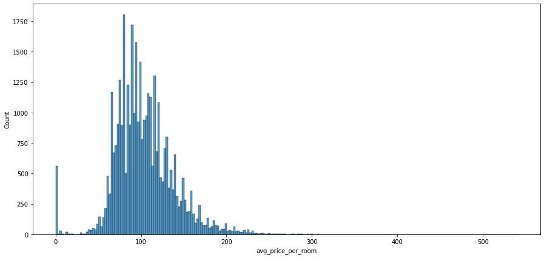

```python
histplot_with_kde(df, 'avg_price_per_room')
```

```python
df['avg_price_per_room'].mean()
```

```
103.42353907649897
```

- The plot is right skewed.
- It is given that the prices are dynamic.
- The average price per day of the reservation is about 103 euros.

```python
df[df['avg_price_per_room'] == 0]['market_segment_type'].value_counts(normalize=True)
```

```
Complementary    0.649541
Online           0.350459
Name: market_segment_type, dtype: float64
```

- 65% of the complementary market segment and remaining 35% of online market segment book for 0 average price per day.

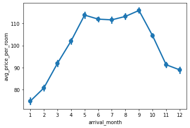

```python
sns.pointplot(data=df, x='arrival_month', y='avg_price_per_room');
plt.show()
```

- Average price per day of the reservation is highest in September, followed by May.
- Bookings are cheaper in January and February. We can relate this with our previous observation, these months were the least busiest.
1. Analysing `no_of_special_requests`

```python
df['no_of_special_requests'].unique()
```

```
array([0, 1, 3, 2, 4, 5])
```

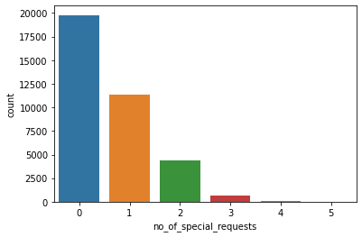

```python
sns.countplot(data=df, x='no_of_special_requests');
plt.show()
```

- In most cases, there are no special requests made by the customer.
- There are bookings with a couple of special requests.

```python
df[df['no_of_special_requests'] > 4].shape[0]
```

```
8
```

- There are 8 bookings with 5 special requests.
1. Analysing `booking_status`

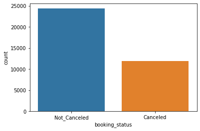

```python
sns.countplot(data=df, x='booking_status');
plt.show()
```

- Most of the bookings were not canceled.

*Qn. 4. What percentage of bookings are canceled?*

```python
canceled_bookings_df = df[df['booking_status'] == 'Canceled']
perc_canceled = canceled_bookings_df.shape[0]/df.shape[0] * 100
print(perc_canceled)
```

```
32.76361130254997
```

*32.76% of the bookings were canceled.*

### Bivariate Analysis

```python
df['booking_status'].unique()
```

```
array(['Not_Canceled', 'Canceled'], dtype=object)
```

```python
# converting values for booking_status, 'Canceled' = 1 and 'Not_Canceled' = 0
df.loc[df['booking_status'] == 'Canceled', 'booking_status'] = 1
df.loc[df['booking_status'] == 'Not_Canceled', 'booking_status'] = 0
```

```python
df['booking_status'].unique()
```

```
array([0, 1], dtype=object)
```

```python
df['booking_status'] = df['booking_status'].astype(int) # converting object datatype to int for easier manipulations
```

```python
df['booking_status'].unique()
```

```
array([0, 1])
```

```
['no_of_adults', 'no_of_children', 'no_of_weekend_nights', 'no_of_week_nights', 'required_car_parking_space', 'lead_time', 'arrival_year', 'arrival_month', 'arrival_date', 'repeated_guest', 'no_of_previous_cancellations', 'no_of_previous_bookings_not_canceled', 'avg_price_per_room', 'no_of_special_r…
```

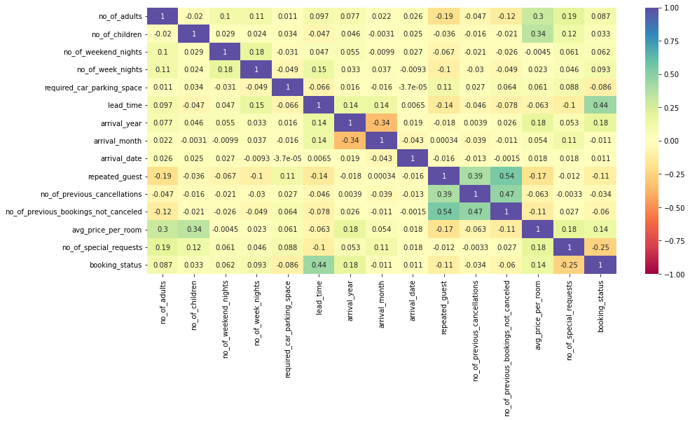

```python
num_col_list = df.select_dtypes(include=np.number).columns.tolist()
print(num_col_list)

plt.figure(figsize=[15,7])
sns.heatmap(df[num_col_list].corr(), annot=True, cmap='Spectral', vmax=1.0, vmin=-1.0);
plt.show()
```

*Qn. 3. Hotel rates are dynamic and change according to demand and customer demographics. What are the differences in room prices in different market segments?*

```python
df_market_segment = df.groupby(['market_segment_type'])
df_market_segment['avg_price_per_room'].mean()
```

```
market_segment_type
Aviation        100.70400
Complementary     3.14176
Corporate        82.91174
Offline          91.63268
Online          112.25685
Name: avg_price_per_room, dtype: float64
```

*The online market segment has the highest average price per room of 112.25 euros, followed by the aviation segment.*

*The complementary segment has the least average price per room of 3.14 euros.*

*Qn. 5. Repeating guests are the guests who stay in the hotel often and are important to brand equity. What percentage of repeating guests cancel?*

```python
repeating_guests_df = df[df['repeated_guest'] == 1]
perc_canceled_repeating_guest = repeating_guests_df[repeating_guests_df['booking_status'] == 'Canceled'].shape[0]/repeating_guests_df.shape[0] * 100
print(perc_canceled_repeating_guest)
```

[output not shown]

*1.72% of the repeating guestes canceled their booking.*

*Qn. 6. Many guests have special requirements when booking a hotel room. Do these requirements affect booking cancellation?*

```python
df['no_of_special_requests'].unique()
```

```
array([0, 1, 3, 2, 4, 5])
```

```python
df[df['booking_status'] == 'Canceled']['no_of_special_requests'].value_counts()
```

[output not shown]

*Booking cancellations are high for zero or minimal(1/2) special requirements.* *No bookings with 3 or more special requirements were canceled.*

## Data Preprocessing

- Missing value treatment (if needed)
- Feature engineering (if needed)
- Outlier detection and treatment (if needed)
- Preparing data for modeling
- Any other preprocessing steps (if needed)
- There were no missing values in the data.
- We have already converted `booking_status` values, 'Canceled' = 1 and 'Not_Canceled' = 0.

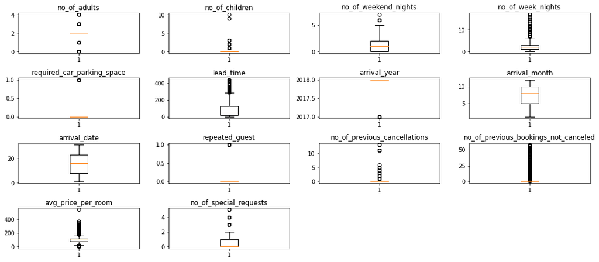

```python
# checking for outliers
num_col_list.remove('booking_status')
plt.figure(figsize=[15,8])

for i, variable in enumerate(num_col_list):
  plt.subplot(5,4,i+1)
  plt.boxplot(df[variable], whis=1.5);
  plt.tight_layout()
  plt.title(variable)
```

```python
df[df['no_of_weekend_nights'] == 7]
```

|  | Booking_ID | no_of_adults | no_of_children | no_of_weekend_nights | no_of_week_nights | type_of_meal_plan | required_car_parking_space | room_type_reserved | lead_time | arrival_year | arrival_month | arrival_date | market_segment_type | repeated_guest | no_of_previous_cancellations | no_of_previous_bookings_not_canceled | avg_price_per_room | no_of_special_requests | booking_status |
| --- | --- | --- | --- | --- | --- | --- | --- | --- | --- | --- | --- | --- | --- | --- | --- | --- | --- | --- | --- |
| 19512 | INN19513 | 2 | 0 | 7 | 17 | Meal Plan 1 | 0 | Room_Type 1 | 188 | 2018 | 7 | 4 | Online | 0 | 0 | 0 | 90.95 | 1 | 1 |

- There are clear outliers in `no_of_children`, `no_of_weekend_nights` and `avg_price_per_room`.
- We shall cap the outliers in `no_of_children` to 3.
- There is a single entry for 17 weeknights, starting July 4 2018. We see there are only 6 weekend nights covered in this time period. Hence, we shall cap the outlier in `no_of_weekend_nights` to 6.
- We shall cap the outliers in `avg_price_per_room` to its upper whisker.

```python
df.loc[df['no_of_children'] == 9, 'no_of_children'] = 3
df.loc[df['no_of_children'] == 10, 'no_of_children'] = 3
```

```python
df.loc[df['no_of_weekend_nights'] == 7, 'no_of_weekend_nights'] = 6
```

```python
Q1 = df['avg_price_per_room'].quantile(0.25)
Q3 = df['avg_price_per_room'].quantile(0.75)
IQR = Q3-Q1
lower_whisker = Q1 - (1.5 * IQR)
upper_whisker = Q3 + (1.5 * IQR)
df.loc[df['avg_price_per_room']>500, 'avg_price_per_room'] = upper_whisker
```

```python
df.drop(['Booking_ID'], axis=1, inplace=True) #Removing Booking_ID as it is a unique value
```

We shall prepare the data for modelling.

```python
X = df.drop(['booking_status'], axis=1) #independent variables
y = df['booking_status'] #dependent variable
```

```python
# adding a constant to the independent variables
X = sm.add_constant(X)
```

```python
# creating dummy variables
X = pd.get_dummies(X, drop_first=True)
```

```python
# splitting data in train and test sets
X_train, X_test, y_train, y_test = train_test_split(
    X, y, test_size=0.30, random_state=1
)
```

```python
X_train.shape
```

```
(25392, 28)
```

```python
X_test.shape
```

```
(10883, 28)
```

## EDA

- It is a good idea to explore the data once again after manipulating it.

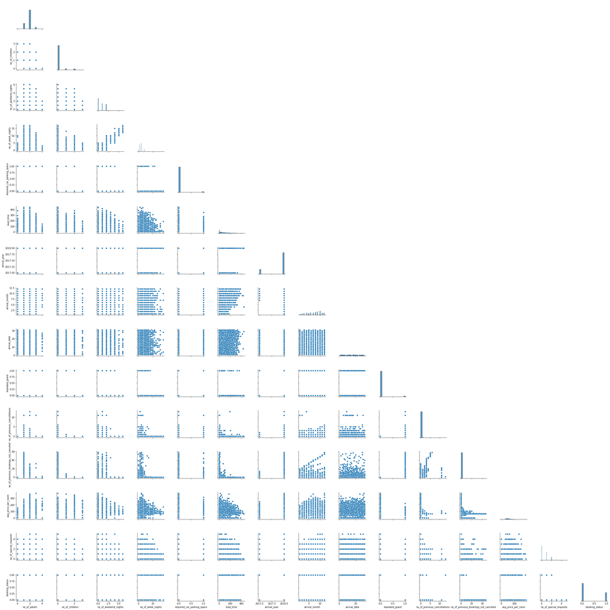

```python
sns.pairplot(data=df, corner=True);
plt.show()
```

We do not see any linear relationship between the attributes and the target variable.

## Building a Logistic Regression model

```python
logit = sm.Logit(y_train, X_train)
lg = logit.fit(disp=False)
print(lg.summary())
```

```
                           Logit Regression Results
==============================================================================
Dep. Variable:         booking_status   No. Observations:                25392
Model:                          Logit   Df Residuals:                    25364
Method:                           MLE   Df Model:                           27
Date:                Sat, 27 Aug 2022   Pseudo R-squ.:                  0.3292
Time:                        19:57:10   Log-Likelihood:                -10794.
converged:                      False   LL-Null:                       -16091.
Covariance Type:            nonrobust   LLR p-value:                     0.000
========================================================================================================
                                           coef    std err          z      P>|z|      [0.025      0.975]
--------------------------------------------------------------------------------------------------------
const                                 -922.8266    120.832     -7.637      0.000   -1159.653    -686.000
no_of_adults                             0.1137      0.038      3.019      0.003       0.040       0.188
no_of_children                           0.1580      0.062      2.544      0.011       0.036       0.280
no_of_weekend_nights                     0.1067      0.020      5.395      0.000       0.068       0.145
no_of_week_nights                        0.0397      0.012      3.235      0.001       0.016       0.064
required_car_parking_space              -1.5943      0.138    -11.565      0.000      -1.865      -1.324
lead_time                                0.0157      0.000     58.863      0.000       0.015       0.016
arrival_year                             0.4561      0.060      7.617      0.000       0.339       0.573
arrival_month                           -0.0417      0.006     -6.441      0.000      -0.054      -0.029
arrival_date                             0.0005      0.002      0.259      0.796      -0.003       0.004
repeated_guest                          -2.3472      0.617     -3.806      0.000      -3.556      -1.139
no_of_previous_cancellations             0.2664      0.086      3.108      0.002       0.098       0.434
no_of_previous_bookings_not_canceled    -0.1727      0.153     -1.131      0.258      -0.472       0.127
avg_price_per_room                       0.0188      0.001     25.396      0.000       0.017       0.020
no_of_special_requests                  -1.4689      0.030    -48.782      0.000      -1.528      -1.410
type_of_meal_plan_Meal Plan 2            0.1756      0.067      2.636      0.008       0.045       0.306
type_of_meal_plan_Meal Plan 3           17.3584   3987.873      0.004      0.997   -7798.729    7833.446
type_of_meal_plan_Not Selected           0.2784      0.053      5.247      0.000       0.174       0.382
room_type_reserved_Room_Type 2          -0.3605      0.131     -2.748      0.006      -0.618      -0.103
room_type_reserved_Room_Type 3          -0.0012      1.310     -0.001      0.999      -2.568       2.566
room_type_reserved_Room_Type 4          -0.2823      0.053     -5.304      0.000      -0.387      -0.178
room_type_reserved_Room_Type 5          -0.7189      0.209     -3.438      0.001      -1.129      -0.309
room_type_reserved_Room_Type 6          -0.9501      0.151     -6.274      0.000      -1.247      -0.653
room_type_reserved_Room_Type 7          -1.4003      0.294     -4.770      0.000      -1.976      -0.825
market_segment_type_Complementary      -40.5976   5.65e+05  -7.19e-05      1.000   -1.11e+06    1.11e+06
market_segment_type_Corporate           -1.1924      0.266     -4.483      0.000      -1.714      -0.671
market_segment_type_Offline             -2.1946      0.255     -8.621      0.000      -2.694      -1.696
market_segment_type_Online              -0.3995      0.251     -1.590      0.112      -0.892       0.093
========================================================================================================
```

The summary contains coefficients of the independent variables and their p-values. These coefficients are in terms of log(odds).

There are two situations where the model predictions can go wrong:

1. Model predicts that booking will not be cancelled, but the booking is actually cancelled.
2. Model predicts that booking will be cancelled, but the booking is actually not cancelled.

Both the cases will have an impact on the hotel's business. Hence, we choose a threshold where the precision and recall are maximum.

We'll start with checking the model performance for threshold=0.5, i.e if (predicted probability > 0.5), the observation is classified as 'booking cancelled'.

```python
#checking model performance on training dataset with threshold=0.5
y_pred_train = lg.predict(X_train) > 0.5
y_pred_train = np.round(y_pred_train)
```

```python
#function to plot the confusion matrix
def draw_confusion_matrix(model, predictors, target, y_predicted):
  cm = confusion_matrix(target, y_predicted)
  labels = np.asarray(
        [
            ["{0:0.0f}".format(item) + "\n{0:.2%}".format(item / cm.flatten().sum())]
            for item in cm.flatten()
        ]
    ).reshape(2, 2)

  plt.figure(figsize=(6, 4))
  sns.heatmap(cm, annot=labels, fmt="")
  plt.ylabel("True label")
  plt.xlabel("Predicted label")
```

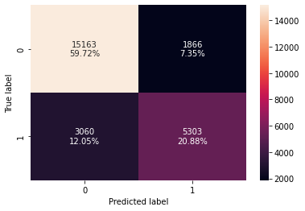

```python
draw_confusion_matrix(lg, X_train, y_train, y_pred_train)
```

```python
#function to calculate accuracy, recall, precision and F1-scores for dataset
def performance_evaluation(actual_value, predicted_value, threshold_used):
  accuracy = accuracy_score(actual_value, predicted_value)
  recall = recall_score(actual_value, predicted_value)
  precision = precision_score(actual_value, predicted_value)
  F1_score = f1_score(actual_value, predicted_value)
  perf_data = pd.DataFrame(
        {"Threshold": threshold_used, "Accuracy": accuracy, "Recall": recall, "Precision": precision, "F1": F1_score,},
        index=[0],
    )
  return (perf_data)
```

```python
performance_evaluation(y_train, y_pred_train, '0.5')
```

|  | Threshold | Accuracy | Recall | Precision | F1 |
| --- | --- | --- | --- | --- | --- |
| 0 | 0.5 | 0.80600 | 0.63410 | 0.73971 | 0.68285 |

## Checking Multicollinearity

- The variables might contain multicollinearity, and the p-values might not be reliable.
- In order to make statistical inferences from a logistic regression model, it is important to ensure that there is no multicollinearity present in the data.

```python
#calculating the variance inflation factor of independent variables in training dataset
vif_series0 = pd.Series([variance_inflation_factor(X_train.values, i) for i in range(X_train.shape[1])], index=X_train.columns)
print(vif_series0)
```

```
const                                  39497686.20788
no_of_adults                                  1.35113
no_of_children                                2.09358
no_of_weekend_nights                          1.06948
no_of_week_nights                             1.09571
required_car_parking_space                    1.03997
lead_time                                     1.39517
arrival_year                                  1.43190
arrival_month                                 1.27633
arrival_date                                  1.00679
repeated_guest                                1.78358
no_of_previous_cancellations                  1.39569
no_of_previous_bookings_not_canceled          1.65200
avg_price_per_room                            2.06860
no_of_special_requests                        1.24798
type_of_meal_plan_Meal Plan 2                 1.27328
type_of_meal_plan_Meal Plan 3                 1.02526
type_of_meal_plan_Not Selected                1.27306
room_type_reserved_Room_Type 2                1.10595
room_type_reserved_Room_Type 3                1.00330
room_type_reserved_Room_Type 4                1.36361
room_type_reserved_Room_Type 5                1.02800
room_type_reserved_Room_Type 6                2.05614
room_type_reserved_Room_Type 7                1.11816
market_segment_type_Complementary             4.50276
market_segment_type_Corporate                16.92829
market_segment_type_Offline                  64.11564
market_segment_type_Online                   71.18026
dtype: float64
```

We start with removing the columns with high p-value, as they are not significant. This will not bring in any significant change in the performance evaluation scores.

```python
print(lg.summary())
```

```
                           Logit Regression Results
==============================================================================
Dep. Variable:         booking_status   No. Observations:                25392
Model:                          Logit   Df Residuals:                    25364
Method:                           MLE   Df Model:                           27
Date:                Tue, 23 Aug 2022   Pseudo R-squ.:                  0.3292
Time:                        21:39:55   Log-Likelihood:                -10794.
converged:                      False   LL-Null:                       -16091.
Covariance Type:            nonrobust   LLR p-value:                     0.000
========================================================================================================
                                           coef    std err          z      P>|z|      [0.025      0.975]
--------------------------------------------------------------------------------------------------------
const                                 -922.8266    120.832     -7.637      0.000   -1159.653    -686.000
no_of_adults                             0.1137      0.038      3.019      0.003       0.040       0.188
no_of_children                           0.1580      0.062      2.544      0.011       0.036       0.280
no_of_weekend_nights                     0.1067      0.020      5.395      0.000       0.068       0.145
no_of_week_nights                        0.0397      0.012      3.235      0.001       0.016       0.064
required_car_parking_space              -1.5943      0.138    -11.565      0.000      -1.865      -1.324
lead_time                                0.0157      0.000     58.863      0.000       0.015       0.016
arrival_year                             0.4561      0.060      7.617      0.000       0.339       0.573
arrival_month                           -0.0417      0.006     -6.441      0.000      -0.054      -0.029
arrival_date                             0.0005      0.002      0.259      0.796      -0.003       0.004
repeated_guest                          -2.3472      0.617     -3.806      0.000      -3.556      -1.139
no_of_previous_cancellations             0.2664      0.086      3.108      0.002       0.098       0.434
no_of_previous_bookings_not_canceled    -0.1727      0.153     -1.131      0.258      -0.472       0.127
avg_price_per_room                       0.0188      0.001     25.396      0.000       0.017       0.020
no_of_special_requests                  -1.4689      0.030    -48.782      0.000      -1.528      -1.410
type_of_meal_plan_Meal Plan 2            0.1756      0.067      2.636      0.008       0.045       0.306
type_of_meal_plan_Meal Plan 3           17.3584   3987.873      0.004      0.997   -7798.729    7833.446
type_of_meal_plan_Not Selected           0.2784      0.053      5.247      0.000       0.174       0.382
room_type_reserved_Room_Type 2          -0.3605      0.131     -2.748      0.006      -0.618      -0.103
room_type_reserved_Room_Type 3          -0.0012      1.310     -0.001      0.999      -2.568       2.566
room_type_reserved_Room_Type 4          -0.2823      0.053     -5.304      0.000      -0.387      -0.178
room_type_reserved_Room_Type 5          -0.7189      0.209     -3.438      0.001      -1.129      -0.309
room_type_reserved_Room_Type 6          -0.9501      0.151     -6.274      0.000      -1.247      -0.653
room_type_reserved_Room_Type 7          -1.4003      0.294     -4.770      0.000      -1.976      -0.825
market_segment_type_Complementary      -40.5976   5.65e+05  -7.19e-05      1.000   -1.11e+06    1.11e+06
market_segment_type_Corporate           -1.1924      0.266     -4.483      0.000      -1.714      -0.671
market_segment_type_Offline             -2.1946      0.255     -8.621      0.000      -2.694      -1.696
market_segment_type_Online              -0.3995      0.251     -1.590      0.112      -0.892       0.093
========================================================================================================
```

```python
X_train1 = X_train.drop(['market_segment_type_Complementary'], axis=1)
logit1 = sm.Logit(y_train, X_train1)
lg1 = logit1.fit(disp=False)
print(lg1.summary())
```

```
                           Logit Regression Results
==============================================================================
Dep. Variable:         booking_status   No. Observations:                25392
Model:                          Logit   Df Residuals:                    25365
Method:                           MLE   Df Model:                           26
Date:                Sat, 27 Aug 2022   Pseudo R-squ.:                  0.3283
Time:                        19:57:23   Log-Likelihood:                -10808.
converged:                       True   LL-Null:                       -16091.
Covariance Type:            nonrobust   LLR p-value:                     0.000
========================================================================================================
                                           coef    std err          z      P>|z|      [0.025      0.975]
--------------------------------------------------------------------------------------------------------
const                                 -922.7227    120.624     -7.650      0.000   -1159.141    -686.304
no_of_adults                             0.1067      0.038      2.840      0.005       0.033       0.180
no_of_children                           0.1532      0.062      2.470      0.014       0.032       0.275
no_of_weekend_nights                     0.1087      0.020      5.503      0.000       0.070       0.147
no_of_week_nights                        0.0419      0.012      3.415      0.001       0.018       0.066
required_car_parking_space              -1.5944      0.138    -11.562      0.000      -1.865      -1.324
lead_time                                0.0157      0.000     58.890      0.000       0.015       0.016
arrival_year                             0.4558      0.060      7.625      0.000       0.339       0.573
arrival_month                           -0.0422      0.006     -6.524      0.000      -0.055      -0.030
arrival_date                             0.0004      0.002      0.210      0.833      -0.003       0.004
repeated_guest                          -2.3219      0.617     -3.762      0.000      -3.532      -1.112
no_of_previous_cancellations             0.2646      0.086      3.088      0.002       0.097       0.433
no_of_previous_bookings_not_canceled    -0.1729      0.152     -1.137      0.256      -0.471       0.125
avg_price_per_room                       0.0191      0.001     26.075      0.000       0.018       0.021
no_of_special_requests                  -1.4699      0.030    -48.840      0.000      -1.529      -1.411
type_of_meal_plan_Meal Plan 2            0.1671      0.067      2.510      0.012       0.037       0.298
type_of_meal_plan_Meal Plan 3            2.2378      1.790      1.250      0.211      -1.271       5.747
type_of_meal_plan_Not Selected           0.2840      0.053      5.356      0.000       0.180       0.388
room_type_reserved_Room_Type 2          -0.3569      0.131     -2.722      0.006      -0.614      -0.100
room_type_reserved_Room_Type 3          -0.0930      1.251     -0.074      0.941      -2.545       2.359
room_type_reserved_Room_Type 4          -0.2808      0.053     -5.276      0.000      -0.385      -0.176
room_type_reserved_Room_Type 5          -0.7350      0.208     -3.526      0.000      -1.143      -0.326
room_type_reserved_Room_Type 6          -0.9649      0.151     -6.378      0.000      -1.261      -0.668
room_type_reserved_Room_Type 7          -1.4394      0.293     -4.917      0.000      -2.013      -0.866
market_segment_type_Corporate           -0.6799      0.250     -2.716      0.007      -1.171      -0.189
market_segment_type_Offline             -1.6769      0.238     -7.051      0.000      -2.143      -1.211
market_segment_type_Online               0.1103      0.235      0.470      0.639      -0.350       0.571
========================================================================================================
```

```python
X_train2 = X_train1.drop(['room_type_reserved_Room_Type 3'], axis=1)
logit2 = sm.Logit(y_train, X_train2)
lg2 = logit2.fit(disp=False)
print(lg2.summary())
```

```
                           Logit Regression Results
==============================================================================
Dep. Variable:         booking_status   No. Observations:                25392
Model:                          Logit   Df Residuals:                    25366
Method:                           MLE   Df Model:                           25
Date:                Sat, 27 Aug 2022   Pseudo R-squ.:                  0.3283
Time:                        19:57:27   Log-Likelihood:                -10808.
converged:                       True   LL-Null:                       -16091.
Covariance Type:            nonrobust   LLR p-value:                     0.000
========================================================================================================
                                           coef    std err          z      P>|z|      [0.025      0.975]
--------------------------------------------------------------------------------------------------------
const                                 -922.7000    120.623     -7.649      0.000   -1159.117    -686.282
no_of_adults                             0.1067      0.038      2.840      0.005       0.033       0.180
no_of_children                           0.1532      0.062      2.470      0.014       0.032       0.275
no_of_weekend_nights                     0.1087      0.020      5.503      0.000       0.070       0.147
no_of_week_nights                        0.0419      0.012      3.416      0.001       0.018       0.066
required_car_parking_space              -1.5944      0.138    -11.562      0.000      -1.865      -1.324
lead_time                                0.0157      0.000     58.890      0.000       0.015       0.016
arrival_year                             0.4558      0.060      7.625      0.000       0.339       0.573
arrival_month                           -0.0422      0.006     -6.525      0.000      -0.055      -0.030
arrival_date                             0.0004      0.002      0.211      0.833      -0.003       0.004
repeated_guest                          -2.3219      0.617     -3.762      0.000      -3.532      -1.112
no_of_previous_cancellations             0.2646      0.086      3.088      0.002       0.097       0.433
no_of_previous_bookings_not_canceled    -0.1729      0.152     -1.137      0.256      -0.471       0.125
avg_price_per_room                       0.0191      0.001     26.075      0.000       0.018       0.021
no_of_special_requests                  -1.4699      0.030    -48.841      0.000      -1.529      -1.411
type_of_meal_plan_Meal Plan 2            0.1671      0.067      2.510      0.012       0.037       0.298
type_of_meal_plan_Meal Plan 3            2.2380      1.790      1.250      0.211      -1.271       5.747
type_of_meal_plan_Not Selected           0.2841      0.053      5.357      0.000       0.180       0.388
room_type_reserved_Room_Type 2          -0.3569      0.131     -2.722      0.006      -0.614      -0.100
room_type_reserved_Room_Type 4          -0.2807      0.053     -5.276      0.000      -0.385      -0.176
room_type_reserved_Room_Type 5          -0.7349      0.208     -3.526      0.000      -1.143      -0.326
room_type_reserved_Room_Type 6          -0.9649      0.151     -6.378      0.000      -1.261      -0.668
room_type_reserved_Room_Type 7          -1.4394      0.293     -4.917      0.000      -2.013      -0.866
market_segment_type_Corporate           -0.6796      0.250     -2.715      0.007      -1.170      -0.189
market_segment_type_Offline             -1.6766      0.238     -7.051      0.000      -2.143      -1.211
market_segment_type_Online               0.1106      0.235      0.471      0.638      -0.350       0.571
========================================================================================================
```

```python
X_train3 = X_train2.drop(['arrival_date'], axis=1)
logit3 = sm.Logit(y_train, X_train3)
lg3 = logit3.fit(disp=False)
print(lg3.summary())
```

```
                           Logit Regression Results
==============================================================================
Dep. Variable:         booking_status   No. Observations:                25392
Model:                          Logit   Df Residuals:                    25367
Method:                           MLE   Df Model:                           24
Date:                Sat, 27 Aug 2022   Pseudo R-squ.:                  0.3283
Time:                        19:57:31   Log-Likelihood:                -10808.
converged:                       True   LL-Null:                       -16091.
Covariance Type:            nonrobust   LLR p-value:                     0.000
========================================================================================================
                                           coef    std err          z      P>|z|      [0.025      0.975]
--------------------------------------------------------------------------------------------------------
const                                 -922.6658    120.627     -7.649      0.000   -1159.091    -686.241
no_of_adults                             0.1069      0.038      2.846      0.004       0.033       0.180
no_of_children                           0.1534      0.062      2.473      0.013       0.032       0.275
no_of_weekend_nights                     0.1088      0.020      5.511      0.000       0.070       0.148
no_of_week_nights                        0.0419      0.012      3.413      0.001       0.018       0.066
required_car_parking_space              -1.5945      0.138    -11.563      0.000      -1.865      -1.324
lead_time                                0.0157      0.000     58.903      0.000       0.015       0.016
arrival_year                             0.4557      0.060      7.624      0.000       0.339       0.573
arrival_month                           -0.0423      0.006     -6.547      0.000      -0.055      -0.030
repeated_guest                          -2.3229      0.617     -3.763      0.000      -3.533      -1.113
no_of_previous_cancellations             0.2645      0.086      3.086      0.002       0.097       0.433
no_of_previous_bookings_not_canceled    -0.1727      0.152     -1.136      0.256      -0.471       0.125
avg_price_per_room                       0.0191      0.001     26.076      0.000       0.018       0.021
no_of_special_requests                  -1.4697      0.030    -48.850      0.000      -1.529      -1.411
type_of_meal_plan_Meal Plan 2            0.1674      0.067      2.515      0.012       0.037       0.298
type_of_meal_plan_Meal Plan 3            2.2395      1.789      1.252      0.211      -1.267       5.746
type_of_meal_plan_Not Selected           0.2842      0.053      5.360      0.000       0.180       0.388
room_type_reserved_Room_Type 2          -0.3565      0.131     -2.719      0.007      -0.613      -0.099
room_type_reserved_Room_Type 4          -0.2806      0.053     -5.273      0.000      -0.385      -0.176
room_type_reserved_Room_Type 5          -0.7348      0.208     -3.525      0.000      -1.143      -0.326
room_type_reserved_Room_Type 6          -0.9649      0.151     -6.378      0.000      -1.261      -0.668
room_type_reserved_Room_Type 7          -1.4391      0.293     -4.916      0.000      -2.013      -0.865
market_segment_type_Corporate           -0.6790      0.250     -2.713      0.007      -1.170      -0.188
market_segment_type_Offline             -1.6771      0.238     -7.053      0.000      -2.143      -1.211
market_segment_type_Online               0.1103      0.235      0.470      0.639      -0.350       0.571
========================================================================================================
```

```python
X_train4 = X_train3.drop(['market_segment_type_Online'], axis=1)
logit4 = sm.Logit(y_train, X_train4)
lg4 = logit4.fit(disp=False)
print(lg4.summary())
```

```
                           Logit Regression Results
==============================================================================
Dep. Variable:         booking_status   No. Observations:                25392
Model:                          Logit   Df Residuals:                    25368
Method:                           MLE   Df Model:                           23
Date:                Sat, 27 Aug 2022   Pseudo R-squ.:                  0.3283
Time:                        19:57:34   Log-Likelihood:                -10808.
converged:                       True   LL-Null:                       -16091.
Covariance Type:            nonrobust   LLR p-value:                     0.000
========================================================================================================
                                           coef    std err          z      P>|z|      [0.025      0.975]
--------------------------------------------------------------------------------------------------------
const                                 -919.9182    120.490     -7.635      0.000   -1156.074    -683.763
no_of_adults                             0.1088      0.037      2.915      0.004       0.036       0.182
no_of_children                           0.1538      0.062      2.480      0.013       0.032       0.275
no_of_weekend_nights                     0.1088      0.020      5.508      0.000       0.070       0.147
no_of_week_nights                        0.0418      0.012      3.405      0.001       0.018       0.066
required_car_parking_space              -1.5956      0.138    -11.573      0.000      -1.866      -1.325
lead_time                                0.0157      0.000     59.175      0.000       0.015       0.016
arrival_year                             0.4544      0.060      7.610      0.000       0.337       0.571
arrival_month                           -0.0425      0.006     -6.585      0.000      -0.055      -0.030
repeated_guest                          -2.3317      0.616     -3.782      0.000      -3.540      -1.123
no_of_previous_cancellations             0.2654      0.086      3.097      0.002       0.097       0.433
no_of_previous_bookings_not_canceled    -0.1727      0.152     -1.135      0.257      -0.471       0.126
avg_price_per_room                       0.0192      0.001     26.336      0.000       0.018       0.021
no_of_special_requests                  -1.4693      0.030    -48.863      0.000      -1.528      -1.410
type_of_meal_plan_Meal Plan 2            0.1661      0.067      2.498      0.012       0.036       0.297
type_of_meal_plan_Meal Plan 3            2.1847      1.755      1.245      0.213      -1.256       5.625
type_of_meal_plan_Not Selected           0.2859      0.053      5.406      0.000       0.182       0.390
room_type_reserved_Room_Type 2          -0.3554      0.131     -2.711      0.007      -0.612      -0.098
room_type_reserved_Room_Type 4          -0.2824      0.053     -5.322      0.000      -0.386      -0.178
room_type_reserved_Room_Type 5          -0.7360      0.208     -3.532      0.000      -1.144      -0.328
room_type_reserved_Room_Type 6          -0.9677      0.151     -6.402      0.000      -1.264      -0.671
room_type_reserved_Room_Type 7          -1.4442      0.293     -4.936      0.000      -2.018      -0.871
market_segment_type_Corporate           -0.7861      0.103     -7.644      0.000      -0.988      -0.585
market_segment_type_Offline             -1.7861      0.052    -34.370      0.000      -1.888      -1.684
========================================================================================================
```

```python
X_train5 = X_train4.drop(['no_of_previous_bookings_not_canceled'], axis=1)
logit5 = sm.Logit(y_train, X_train5)
lg5 = logit5.fit(disp=False)
print(lg5.summary())
```

```
                           Logit Regression Results
==============================================================================
Dep. Variable:         booking_status   No. Observations:                25392
Model:                          Logit   Df Residuals:                    25369
Method:                           MLE   Df Model:                           22
Date:                Sat, 27 Aug 2022   Pseudo R-squ.:                  0.3283
Time:                        19:57:37   Log-Likelihood:                -10809.
converged:                       True   LL-Null:                       -16091.
Covariance Type:            nonrobust   LLR p-value:                     0.000
==================================================================================================
                                     coef    std err          z      P>|z|      [0.025      0.975]
--------------------------------------------------------------------------------------------------
const                           -918.3092    120.502     -7.621      0.000   -1154.488    -682.130
no_of_adults                       0.1088      0.037      2.913      0.004       0.036       0.182
no_of_children                     0.1537      0.062      2.480      0.013       0.032       0.275
no_of_weekend_nights               0.1087      0.020      5.505      0.000       0.070       0.147
no_of_week_nights                  0.0417      0.012      3.402      0.001       0.018       0.066
required_car_parking_space        -1.5950      0.138    -11.567      0.000      -1.865      -1.325
lead_time                          0.0157      0.000     59.218      0.000       0.015       0.016
arrival_year                       0.4536      0.060      7.596      0.000       0.337       0.571
arrival_month                     -0.0425      0.006     -6.584      0.000      -0.055      -0.030
repeated_guest                    -2.7375      0.557     -4.918      0.000      -3.828      -1.646
no_of_previous_cancellations       0.2289      0.077      2.984      0.003       0.079       0.379
avg_price_per_room                 0.0192      0.001     26.347      0.000       0.018       0.021
no_of_special_requests            -1.4698      0.030    -48.882      0.000      -1.529      -1.411
type_of_meal_plan_Meal Plan 2      0.1652      0.067      2.483      0.013       0.035       0.296
type_of_meal_plan_Meal Plan 3      2.1852      1.757      1.244      0.214      -1.258       5.629
type_of_meal_plan_Not Selected     0.2860      0.053      5.406      0.000       0.182       0.390
room_type_reserved_Room_Type 2    -0.3556      0.131     -2.712      0.007      -0.613      -0.099
room_type_reserved_Room_Type 4    -0.2826      0.053     -5.326      0.000      -0.387      -0.179
room_type_reserved_Room_Type 5    -0.7361      0.208     -3.534      0.000      -1.144      -0.328
room_type_reserved_Room_Type 6    -0.9683      0.151     -6.405      0.000      -1.265      -0.672
room_type_reserved_Room_Type 7    -1.4448      0.293     -4.938      0.000      -2.018      -0.871
market_segment_type_Corporate     -0.7910      0.103     -7.689      0.000      -0.993      -0.589
market_segment_type_Offline       -1.7861      0.052    -34.372      0.000      -1.888      -1.684
==================================================================================================
```

```python
X_train6 = X_train5.drop(['type_of_meal_plan_Meal Plan 3'], axis=1)
logit6 = sm.Logit(y_train, X_train6)
lg6 = logit6.fit(disp=False)
print(lg6.summary())
```

```
                           Logit Regression Results
==============================================================================
Dep. Variable:         booking_status   No. Observations:                25392
Model:                          Logit   Df Residuals:                    25370
Method:                           MLE   Df Model:                           21
Date:                Sat, 27 Aug 2022   Pseudo R-squ.:                  0.3282
Time:                        19:57:40   Log-Likelihood:                -10810.
converged:                       True   LL-Null:                       -16091.
Covariance Type:            nonrobust   LLR p-value:                     0.000
==================================================================================================
                                     coef    std err          z      P>|z|      [0.025      0.975]
--------------------------------------------------------------------------------------------------
const                           -915.6391    120.471     -7.600      0.000   -1151.758    -679.520
no_of_adults                       0.1088      0.037      2.914      0.004       0.036       0.182
no_of_children                     0.1531      0.062      2.470      0.014       0.032       0.275
no_of_weekend_nights               0.1086      0.020      5.498      0.000       0.070       0.147
no_of_week_nights                  0.0417      0.012      3.399      0.001       0.018       0.066
required_car_parking_space        -1.5947      0.138    -11.564      0.000      -1.865      -1.324
lead_time                          0.0157      0.000     59.213      0.000       0.015       0.016
arrival_year                       0.4523      0.060      7.576      0.000       0.335       0.569
arrival_month                     -0.0425      0.006     -6.591      0.000      -0.055      -0.030
repeated_guest                    -2.7367      0.557     -4.916      0.000      -3.828      -1.646
no_of_previous_cancellations       0.2288      0.077      2.983      0.003       0.078       0.379
avg_price_per_room                 0.0192      0.001     26.336      0.000       0.018       0.021
no_of_special_requests            -1.4698      0.030    -48.884      0.000      -1.529      -1.411
type_of_meal_plan_Meal Plan 2      0.1642      0.067      2.469      0.014       0.034       0.295
type_of_meal_plan_Not Selected     0.2860      0.053      5.406      0.000       0.182       0.390
room_type_reserved_Room_Type 2    -0.3552      0.131     -2.709      0.007      -0.612      -0.098
room_type_reserved_Room_Type 4    -0.2828      0.053     -5.330      0.000      -0.387      -0.179
room_type_reserved_Room_Type 5    -0.7364      0.208     -3.535      0.000      -1.145      -0.328
room_type_reserved_Room_Type 6    -0.9682      0.151     -6.403      0.000      -1.265      -0.672
room_type_reserved_Room_Type 7    -1.4343      0.293     -4.892      0.000      -2.009      -0.860
market_segment_type_Corporate     -0.7913      0.103     -7.692      0.000      -0.993      -0.590
market_segment_type_Offline       -1.7854      0.052    -34.363      0.000      -1.887      -1.684
==================================================================================================
```

Now we observe that the remaining independent variables have p-value less than 0.05.

X_train_final = X_train6

Final logistic regression model = lg6

```python
X_train_final = X_train6
```

The coefficients of the independent variables are in terms of log(odds). To find the odds, we take the exponential of the coefficients.

odds = exp(coefficients)

percentage change in odds = (exp(coefficients) - 1) * 100

```python
#calculating odds from coefficients
odds = np.exp(lg6.params)
interpret_coeffts = pd.DataFrame(odds, X_train_final.columns, columns=['Odds']).T
#calculating the percentage change in odd
perc_change_odds = (np.exp(lg6.params) - 1) * 100
interpret_coeffts = interpret_coeffts.append(pd.DataFrame(perc_change_odds, X_train_final.columns, columns=['Change_Odds%']).T)
interpret_coeffts.T
```

|  | Odds | Change_Odds% |
| --- | --- | --- |
| const | 0.00000 | -100.00000 |
| no_of_adults | 1.11491 | 11.49096 |
| no_of_children | 1.16546 | 16.54593 |
| no_of_weekend_nights | 1.11470 | 11.46966 |
| no_of_week_nights | 1.04258 | 4.25841 |
| required_car_parking_space | 0.20296 | -79.70395 |
| lead_time | 1.01583 | 1.58331 |
| arrival_year | 1.57195 | 57.19508 |
| arrival_month | 0.95839 | -4.16120 |
| repeated_guest | 0.06478 | -93.52180 |
| no_of_previous_cancellations | 1.25712 | 25.71181 |
| avg_price_per_room | 1.01937 | 1.93684 |
| no_of_special_requests | 0.22996 | -77.00374 |
| type_of_meal_plan_Meal Plan 2 | 1.17846 | 17.84641 |
| type_of_meal_plan_Not Selected | 1.33109 | 33.10947 |
| room_type_reserved_Room_Type 2 | 0.70104 | -29.89588 |
| room_type_reserved_Room_Type 4 | 0.75364 | -24.63551 |
| room_type_reserved_Room_Type 5 | 0.47885 | -52.11548 |
| room_type_reserved_Room_Type 6 | 0.37977 | -62.02290 |
| room_type_reserved_Room_Type 7 | 0.23827 | -76.17294 |
| market_segment_type_Corporate | 0.45326 | -54.67373 |
| market_segment_type_Offline | 0.16773 | -83.22724 |

- `no_of_adults` - Holding all other features constant, a unit increase in the number of adults increases the odds by 1.11 times or 11.49% increase in odds of cancellation.
- `no_of_children` - Holding all other features constant, a unit increase in the number of children increases the odds by 1.16 times or 16.54% increase in odds of cancellation.
- `no_of_weekend_nights` - Holding all other features constant, a unit increase in the number of weekend nights increases the odds by 1.11 times or 11.46% increase in odds of cancellation.
- `no_of_week_nights` - Holding all other features constant, a unit increase in the number of week nights increases the odds by 1.04 times or 4.25% increase in odds of cancellation.
- `required_car_parking_space` - Holding all other features constant, if the customer requires car parking space, it decreases the odds by 0.2 times or 79.7% decrease in odds of cancellation.
- `repeated_guest` - Holding all other features constant, if the customer is a repeated guest, it decreases the odds by 0.064 times or 93.52% decrease in odds of cancellation.
- `no_of_previous_cancellations` - Holding all other features constant, a unit increase in the number of previous bookings that were canceled by the customer prior to the current booking increases the odds by 1.25 times or 25.7% increase in odds of cancellation.
- `no_of_special_requests` - Holding all other features constant, if total number of special requests made by the customer increases by one unit, it decreases the odds by 0.2 times or 77% decrease in odds of cancellation.
- `type_of_meal_plan` - Holding all other features constant, if the customer does not prefer any meal plan offered by the hotel, it increases the odds by 1.33 times or 33% increase in odds of cancellation, compared to choosing a meal plan.
- `room_type_reserved` - Holding all other features constant, if the type of room reserved by the customer is Type 7, it decreases the odds by 0.23 times or 76% decrease in odds of cancellation. This is followed by Type 6, with the decrease in odds of cancellation by 0.379 times or 62% decrease. Reserving room type 5 decreases the odds of cancellation by 0.48 times or 52% decrease.
- `market_segment` - Holding all other features constant, if the market segment is Offline, it decreases the odds by 0.167 times or 83% decrease in odds of cancellation. This is followed by the corporate segment, with the decrease in odds of cancellation by 0.45 times or 54.67% decrease.

## Model performance evaluation

We start with a threshold of 0.5

```python
#checking model performance on training dataset with threshold=0.5
y_pred_train1 = lg6.predict(X_train_final) > 0.5
y_pred_train1 = np.round(y_pred_train1)
```

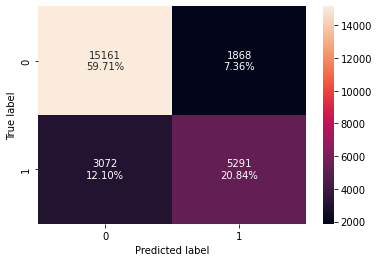

```python
draw_confusion_matrix(lg6, X_train_final, y_train, y_pred_train1)
```

```python
perf_train_1 = performance_evaluation(y_train, y_pred_train1, '0.5')
display(perf_train_1)
```

|  | Threshold | Accuracy | Recall | Precision | F1 |
| --- | --- | --- | --- | --- | --- |
| 0 | 0.5 | 0.80545 | 0.63267 | 0.73907 | 0.68174 |

We observe that there is no significant change in the performance evaluation scores, after dropping independent variables with high p-value.

Plotting the ROC-AUC curve on training set

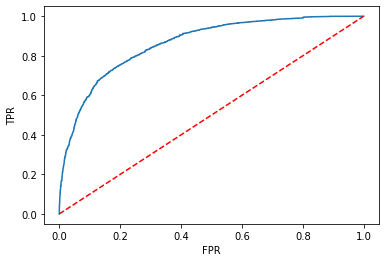

```python
logit_roc_auc_train = roc_auc_score(y_train, lg6.predict(X_train_final))
fpr, tpr, thresholds = roc_curve(y_train, lg6.predict(X_train_final))
plt.plot(fpr, tpr)
plt.plot([0,1],[0,1], 'r--')
plt.xlabel('FPR')
plt.ylabel('TPR')
plt.show()
```

Predicting the test data using the final logistic regression model

```python
print(X_train_final.columns)
```

```
Index(['const', 'no_of_adults', 'no_of_children', 'no_of_weekend_nights',
       'no_of_week_nights', 'required_car_parking_space', 'lead_time',
       'arrival_year', 'arrival_month', 'repeated_guest',
       'no_of_previous_cancellations', 'avg_price_per_room',
       'no_of_special_requests', 'type_of_meal_plan_Meal Plan 2',
       'type_of_meal_plan_Not Selected', 'room_type_reserved_Room_Type 2',
       'room_type_reserved_Room_Type 4', 'room_type_reserved_Room_Type 5',
       'room_type_reserved_Room_Type 6', 'room_type_reserved_Room_Type 7',
       'market_segment_type_Corporate', 'market_segment_type_Offline'],
      dtype='object')
```

```python
print(X_test.columns)
```

```
Index(['const', 'no_of_adults', 'no_of_children', 'no_of_weekend_nights',
       'no_of_week_nights', 'required_car_parking_space', 'lead_time',
       'arrival_year', 'arrival_month', 'arrival_date', 'repeated_guest',
       'no_of_previous_cancellations', 'no_of_previous_bookings_not_canceled',
       'avg_price_per_room', 'no_of_special_requests',
       'type_of_meal_plan_Meal Plan 2', 'type_of_meal_plan_Meal Plan 3',
       'type_of_meal_plan_Not Selected', 'room_type_reserved_Room_Type 2',
       'room_type_reserved_Room_Type 3', 'room_type_reserved_Room_Type 4',
       'room_type_reserved_Room_Type 5', 'room_type_reserved_Room_Type 6',
       'room_type_reserved_Room_Type 7', 'market_segment_type_Complementary',
       'market_segment_type_Corporate', 'market_segment_type_Offline',
       'market_segment_type_Online'],
      dtype='object')
```

```python
#dropping independent variables not available in training data
X_test1 = X_test.drop(['arrival_date', 'no_of_previous_bookings_not_canceled',
                       'type_of_meal_plan_Meal Plan 3', 'room_type_reserved_Room_Type 3',
                       'market_segment_type_Complementary', 'market_segment_type_Online'], axis=1)
```

```python
X_test_final = X_test1
```

```python
#checking model performance on testing dataset with threshold=0.5
y_pred_test1 = lg6.predict(X_test_final) > 0.5
y_pred_test1 = np.round(y_pred_test1)
```

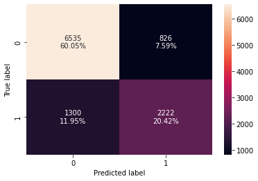

```python
draw_confusion_matrix(lg6, X_test_final, y_test, y_pred_test1)
```

```python
perf_test_1 = performance_evaluation(y_test, y_pred_test1, '0.5')
display(perf_test_1)
```

|  | Threshold | Accuracy | Recall | Precision | F1 |
| --- | --- | --- | --- | --- | --- |
| 0 | 0.5 | 0.80465 | 0.63089 | 0.72900 | 0.67641 |

We observe that the performance evaluation scores of training dataset and testing dataset using our regression model are quite close for 0.5 threshold.

To improve the model performance, we find the optimal threshold value from the ROC-AUC curve.

Optimum value will be that point in ROC-AUC curve, where the (TPR-FPR) is the maximum.

```python
optimal_ids = np.argmax(tpr-fpr)
optimal_threshold_value = thresholds[optimal_ids]
print(optimal_threshold_value)
```

```
0.3700522558707859
```

As per the ROC-AUC curve, the optimal value of threshold is 0.37.

```python
#checking model performance on training dataset with threshold=0.37
y_pred_train2 = lg6.predict(X_train_final) > 0.37
y_pred_train2 = np.round(y_pred_train2)
```

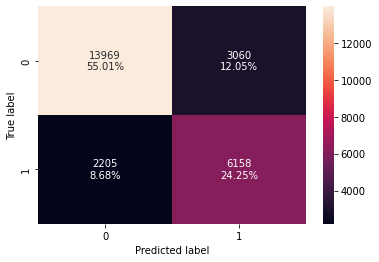

```python
draw_confusion_matrix(lg6, X_train_final, y_train, y_pred_train2)
```

```python
perf_train_2 = performance_evaluation(y_train, y_pred_train2, '0.37')
display(perf_train_2)
```

|  | Threshold | Accuracy | Recall | Precision | F1 |
| --- | --- | --- | --- | --- | --- |
| 0 | 0.37 | 0.79265 | 0.73634 | 0.66804 | 0.70053 |

We observe that the accuracy value slightly reduced, but the recall score improved very well when the threshold was changed from 0.5 to 0.37

```python
#checking model performance on testing dataset with threshold=0.37
y_pred_test2 = lg6.predict(X_test_final) > 0.37
y_pred_test2 = np.round(y_pred_test2)
```

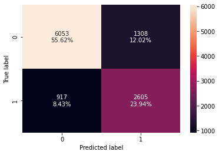

```python
draw_confusion_matrix(lg6, X_test_final, y_test, y_pred_test2)
```

```python
perf_test_2 = performance_evaluation(y_test, y_pred_test2, '0.37')
display(perf_test_2)
```

|  | Threshold | Accuracy | Recall | Precision | F1 |
| --- | --- | --- | --- | --- | --- |
| 0 | 0.37 | 0.79555 | 0.73964 | 0.66573 | 0.70074 |

For better threshold, we use the precision-recall curve and maximise the F1 score.

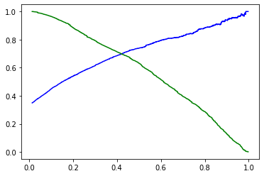

```python
y_pred_train3 = lg6.predict(X_train_final)
prec, rec, thresh = precision_recall_curve(y_train, y_pred_train3)
plt.plot(thresh, prec[:-1], color='blue')
plt.plot(thresh, rec[:-1], color='green')
plt.show()
```

From the precision-recall curve, we observe that the precision and recall intersect at 0.42.